# HRV analysis

## HRV analysis

This document contains the analysis of the heart rate variabillity from an ECG recording of piglet number 2348. This recording was taken on the 8/11/2018 using the CFM data aquisition system from Inspiration technologies. The data was sampled at $256Hz$ with a high pass cutoff at 20Hz, and a 50Hz notch filter. Beat annotations were applied using a script written in MATLAB that uses the maximal overlap discrete wavelet transform $(MODWT)$ to enhance the R peaks in the ECG waveform. Then I used the r squared absolute value of the signal approximation built from the wavelet coefficients to employ a Signal Processing Toolbox peak finding algorithm to identify the R peaks.The beat positions in time were then saved as an ascii text file.

## Build a non-interpolated HR data structure

The first step in my analysis is to build the non-interpolated HRV data structure and extract the appropriate time segments and annotate them appropriatly.

```
##  Calculating non-interpolated heart rate
```

```
##  Number of beats: 5324
```

[output not shown]

[output cut: 5329 more lines]

## Interpolation of the HR file.

In order to perform frequency and nonlinear analytical techniques a time series with uniformly distributed datapoints must be used, the process by which this is done is called interpolation. Many different interpolation algorithms can be found in the literature. The most usual are linear or cubic splines interpolation, but many others can be used. The RHRV package allows either linear or cubic splines interpolation. The sampling frequency to obtain the equally spaced heart rate signal has to be set in both; the default is 4 Hz, ideal for adult human signals; I have chosen to sample at 8Hz, given that the HR of the neonatal pig is appproximatly double a human adult HR. The outcome of this step yeilds, a new heart rate signal that is adequate for performing spectral analysis, as well as time and nonlinear studies. I have chosen to use the cubic splines interpolation because it seems to give more resolution on a graph.

### Filtering the HR file

The RHRV software package provides a GUI inerface for removing aritifacts and nonsensical beats.

```r
hrv.data <- BuildNIHR(hrv.data) #Building the non-interpolated heart rate signal ----
```

```
##  Calculating non-interpolated heart rate
```

```
##  Number of beats: 5324
```

```r
#hrv.data <- FilterNIHR(hrv.data) # filtering the non-interpolated signal
hrv.data <- EditNIHR(hrv.data) #manual removal of outliers can be performed with
```

```
##  Manually editing non-interpolated instantaneous heart rate
```

```
##  Point clicked: (-20.9392474806407, 233.958593653631)
```

```
##  Point clicked: (682.623295688959, 197.632119605732)
```

```
##  3 points found in area
```

```
##  Removing 3 points (3 so far)
```

```
##  Point clicked: (95.2742083107663, 137.783292698166)
```

```
##  Point clicked: (1672.00812202121, 72.6305826979383)
```

```
##  5 points found in area
```

```
##  Removing 5 points (8 so far)
```

```
##  Manual edition ended... quitting
```

```r
## Interpolation of instantaneous heart rate ----
hrv.data2 <- InterpolateNIHR(hrv.data, freqhr = 8, method = "linear")
```

```
##  Interpolating instantaneous heart rate
```

```
##  Frequency: 8 Hz
```

```
##  Number of beats: 5316
```

```
##  Number of points: 14398
```

```r
hrv.data <- InterpolateNIHR(hrv.data, freqhr = 8, method = "spline")
```

```
##  Interpolating instantaneous heart rate
```

```
##  Frequency: 8 Hz
```

```
##  Number of beats: 5316
```

```
##  Number of points: 14398
```

```r
PlotNIHR(hrv.data)
```

```
##  Plotting non-interpolated instantaneous heart rate
```

```
##  Number of points: 5316
```

```r
#These show a comparison of the two methods used to interpolate the HR.
P1 <- PlotHR(hrv.data, Tags = "all", main = "Spline interpolated HR") #  Graph the spline interpolated HRV with base R
```

```
##  Plotting interpolated instantaneous heart rate
```

```
##  Number of points: 14398
```

```
##  Plotting interpolated instantaneous heart rate
##  Number of points: 14398
```

[figure not shown]

[figure not shown]

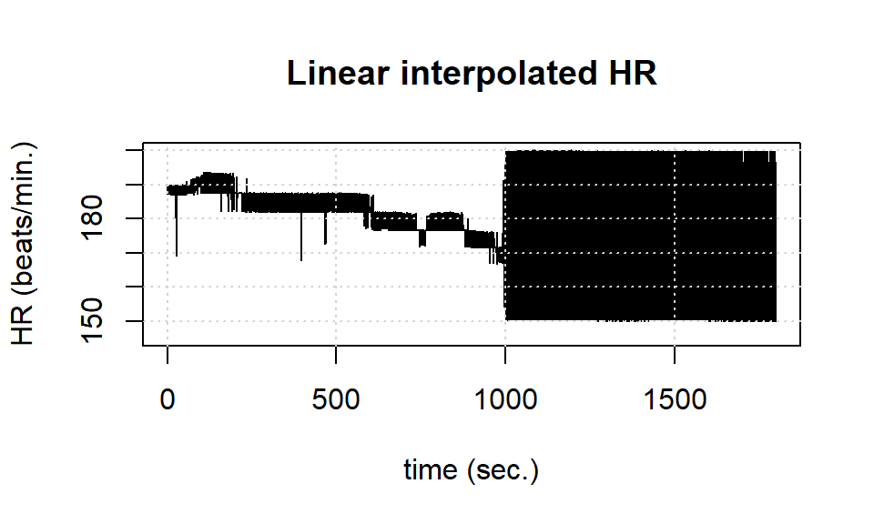

```r
P2 <- PlotHR(hrv.data2, Tags = "all", main = "Linear interpolated HR") #Graph the linear interpolated HRV with base R
```

### Time-domain analysis of each segment.

There are several outputs of the time domain analysis function.

The instantaneous heart rate is defined:

where $Time[i]$ is the time when the beat $i$ occurs, measured in seconds, $RR[i]$ is the beat-to-beat distance, measured in milliseconds, and $HR(i)$ is the instantaneous heart rate, measured in beats per minute.

Researchers have proposed an extensive number of Time-domain indecies. The arithmetic mean of the RR interval series, RR, can be defined as follows:

$$\overline{RR} = \frac{1}{N} \sum_{i=1}^{n} RR_i$$
Being N the length of the RR series, and $RR_i$ the $RR$ interval between beats $i$ and $i â 1$, where each beat position corresponds to the beat detection instant.

SDNN is the standard deviation of the RR interval series:

$$SDNN = \sqrt {\frac{1}{N-1} \sum_{i=1}^{n} (RR_i - \overline{RR})^2}$$

$SDNN$ reflects the global variability of the series. However, SDNN value depends on the length of the recording, and therefore, durations of recording should be standardized in order to obtain comparable results. As discussed in, both short-term (5 min) and long-term (24 h) recordings are commonly used to calculate SDNN as well as another HRV measures.

Other time-domain measures are estimated from segments of the total recording, usually 5 min. For instance, $SDANN$ is the standard deviation of the means of these segments, while $SDNNIDX$ is the mean of the standard deviations of these same segments. To compute these indices, the RR series is divided into fragments 5 min long, and mean and standard deviation of RR distances can be calculated for each fragment:

$$\overline{RR}_s = \frac{1}{N_s} \sum_{i=1}^{N_s} RR_i$$

$$SDNN_s = \sqrt{ \frac{1}{N-1} \sum_{i=1}^{n} (RR_i - \overline{RR})^2}$$
ô° where $RRs$ and $SDNNs$ are the mean and the standard deviation, respectively, of the $RR$ distances in fragment $s$, and $N$ is the number of elements in this fragment. As said, $SDANN$ is the standard deviation of the means of all the fragments, and $SDNNIDX$ is the mean of the standard deviations of all fragments:

$$\overline{RR}_{alls} = \frac{1}{m} \sum_{s=1}^{m} \overline{RR_s}$$

$$SDANN = \sqrt{ \frac{1}{m-1} \sum_{s=1}^{m} (RR_s - \overline{RR})^2}$$

$$SDNNIDX = \frac{1}{m} \sum_{s=1}^m SDNN_s$$

where $RR_{alls}$ is the mean of all segments, and m is the total number of segments. $SDANN$ evaluates long-term variability, due to cycles longer than 5 min, and $SDNNIDX$ quantifies short-term variability, because of cycles shorter than 5 min.

Indexes based on the difference between adjacent RR values quantify the power due to high-frequency components. The most used are $pNN50$, $SDSD$, and $r-MSSD$. $pNN50$ is the proportion of values of the RR series that differ from the previous value more than 50 ms:

$$r - MSSD = \sqrt{\frac{1}{N-1} \sum_{j=i}^{N-1} \Delta RR_j^{2}}$$

These three short-term measurements estimate high-frequency variations and, therefore, show high correlation with each other. Other similar indices are $IRRR$ and $MADRR$, correlated with $SDNN$ and $pNN50$, respectively, and that solve some of their problems. $IRRR$ is the interquartile range, that is, the difference between the third and the first quartile of the RR series, and it is a very robust measure against artifacts:

$$IRRR = Q3 (\Delta RR) - Q1(\Delta RR)$$

Quartiles are defined as the three values of the points that divide the ordered data set into four equally sized groups. The first quartile $(Q1)$ splits off the lowest 25% of the RR values, and the third quartile $(Q3)$ splits off the highest 25% of the RR values. If the RR series has a Gaussian distribution, $IRRR$ is an estimation of standard deviation (overall HRV).

MADRR is the median of the absolute differences between adjacent RR values and does not suffer from saturation problems as pNN50. Similar to pNN50, MADRR measures the power due to high-frequency components. This median is calculated as the second quartile (Q2) of $|ÎRR|$:

$$MADRR = Q2(|ÎRR|)$$

In addition to these statistical parameters, there are some geometric measures that can be estimated from the RR interval histogram, such as $TINN$ and the HRV index, in order to avoid the negative influence of artifacts in the determination of variability indexes. A bin of approximately 8 ms (exactly 7.8125 ms) can be used to construct smoothed histograms.

$TINN$ is the baseline width of the triangular interpolation of the RR intervals histogram. $TINN$ may be calculated as the total area of the histogram of the RR series, divided by the maximum of the histogram multiplied by 2:

$$TINN = \frac {N · bin size} {max(histogram(RR))} · 2$$

An approximation to this measure is the $HRV index$. The HRV index is the integral of the intervals histogram (the number of all $RR$ intervals, that is, the length of the $RR$ series) divided by the maximum of the intervals histogram. The HRV index does not need triangular interpolation, and it is dimensionless:

$$HRV index = N max(histogram(RR))$$

Both measures, $TINN$ and $HRV index$, reflect overall HRV and are more influenced by the lower than by the higher frequencies.

It should be noted that it is not necessary to perform the interpolation process before applying the time-domain techniques, since these parameters are calculated directly from the noninterpolated RR-time series. In this example, default parameters are used, although the following arguments can be used:

â¢ size: length of segments in which the RR series is divided (default: 300 seconds). â¢ numofbins: number of bins in RR histogram; when not specified, the interval parameter is used (default). â¢ interval: width of bins in RR histogram (default: 7.8125 ms).

#### Time Domain Analysis code:

```r
hrv.data <- CreateTimeAnalysis(hrv.data)
```

```
##  Creating time analysis
```

```
##  Size of window: 300 seconds
```

```
##  Width of bins in histogram: 7.8125 milliseconds
```

```
##  Number of windows: 5
```

```
##  Data has now 1 time analyses
##    SDNN: 35.3837 msec.
##    SDANN: 13.6104 msec.
##    SDNNIDX: 21.2197 msec.
##    pNN50: 40.5268 %
##    SDSD: 63.9258 msec.
##    r-MSSD: 63.9198 msec.
##    IRRR: 34 msec.
##    MADRR: 10 msec.
##    TINN: 72.6706 msec.
##    HRV index: 4.6509
```

```r
#INJ <- ExtractTimeSegment(hrv.data, 210, 800)
#REC <- ExtractTimeSegment(hrv.data, 500, 900)
#PI_24h <-ExtractTimeSegment(hrv.data, 700, 900)


#print("Time-domain analysis for the period of HI injury")
#INJ <- CreateTimeAnalysis(INJ)

#print("Time-domain analysis for the period of recovery")
#REC <- CreateTimeAnalysis(REC)

#print("Time domain analysis for 24 hours post insult")
#PI_24h <- CreateTimeAnalysis(PI_24h)
```

# Step 2: Frequency analysis

To be able to study nonstationary signals, several techniques capable of representing a signal in both time and frequency domain have been developed. The key idea behind these time-frequency joint representations is to define elementary time-frequency atoms as waveforms with minimum spread in the time-frequency plane. Then, these time-frequency atoms (instead of the infinite time spread sines and cosines) are used to decompose the signals. Selecting the time-frequency atoms is not a trivial problem because of the time-frequency uncertainty principle: The energy spread of a function and its Fourier Transform cannot simultaneously be arbitrarily small.

One of the most common time-frequency decompositions for discrete signals is the Short-Time Fourier Transform $(STFT)$, which uses a symmetric window to select an interval of the signal that is going to be analyzed. The remaining signal is analyzed by repeatedly shifting the window in time. Often these shifts are made in such a way that the multiple time-windows used have a certain degree of overlap between them. In order to sample the frequency interval with $M$ equally spaced frequencies, the practical implementation of the $STFT$ of the $RR$ series is given by:

$$X_{r,k} = \sum^{Lâ1}_{n=0} RR_{rR+n} Â· w_ne^{-2 \pi ki \frac{n}{M}}$$

$$Ï_{u,s}(t) = \frac {1} {\sqrt{s}}Ï(\frac{t-u}{s})$$

where $s$ is positive and defines the scale, and u is any real number defining the shift. This set of functions is used to extract time-frequency information by correlating them with the signal $f (t)$ being analyzed:

where $[WÏ f ](u, s)$ is the $WT$ of the signal $f (t)$ using the mother wavelet $Ï$. When working with discrete signals, and if the proper set of orthonormal wavelets is used in the decomposition, it is possible to efficiently compute the $WT$ as a set of conjugate mirror filters and subsampling operations.

The $WT$ provides a better compromise between time and frequency resolution than the $STFT$. The $STFT$ uses just one window to analyze the signal. However, the ideal approximation would be to use narrow windows at high frequencies, and wide windows at low frequencies. The Wavelet Transform uses multiple windows, obtained by applying dilatations to the mother wavelet, leading to a multiresolution analysis. In the literature, there are more $HRV$ studies that use the $STFT$ than studies that use the WT, despite the theoretically superior properties of the latter. I believe that the main reason for this is the historical lack of HRV analysis tools with support for spectral analysis based on $WT$, and the greater complexity of implementing manually these algorithms. When I perform a spectral analysis with RHRV, I will use both techniques and compare the results.

## An Overview of Fractal Dynamics

The power spectrum of a fractal signal fulfils the power law relationship

where Î² is the spectral index. Signals with this type of power spectrum are referred to as 1/f noises. 1/f noises with â1 < Î² < 1 and 1 < Î² < 3 can be approximated by fGn and fBm-signals, respectively.

If $Î²Ë$ â 1$, there is uncertainty about the nature of the signal. Once the signal has been classified, I may obtain the Hurst exponent using

```r
hrv.data <- CreateNonLinearAnalysis(hrv.data)
```

```
##  Creating non linear analysis
```

```
##  Data has now  1  nonlinear analysis
```

```r
# Raw periodogram
hrv.data <- CreateFreqAnalysis(hrv.data)
```

```
##  Creating frequency analysis
```

```
##  Data has now 1 frequency analysis
```

```r
hrv.data <- CalculatePSD(hrv.data, indexFreqAnalysis = 1, method = "pgram", doPlot = F)
```

```
##  Calculating Periodogram using DFT + Daniell smoothers
```

```
##  Calculating spectral index
```

```
##  Plotting PSD
```

```
##  Spectral index = 1.9408
```

```
##  H_fBm = 0.4704
```

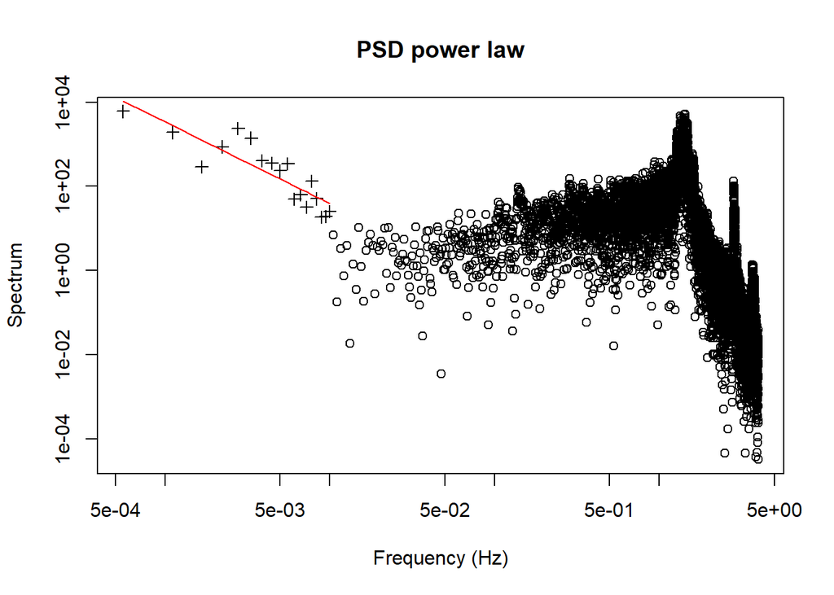

```r
hrv.data <- EstimatePSDSlope(hrv.data, indexFreqAnalysis = 1, regressionRange = NULL, doPlot = T, main = "PSD power law", xlab = "Frequency (Hz)", ylab = "Spectrum")
```

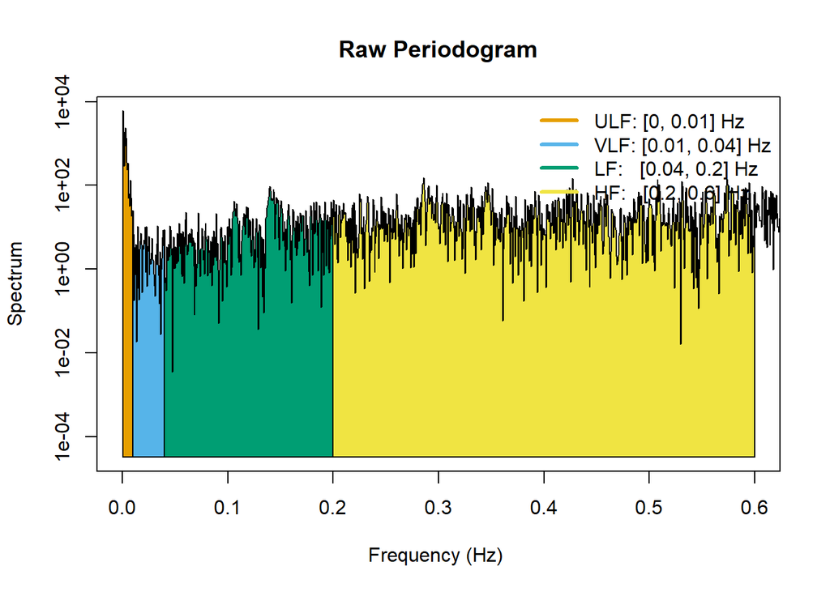

```r
PlotPSD(hrv.data, 1, addlegend = TRUE, ULFmin = 0, ULFmax = 0.01, VLFmin = 0.01, VLFmax = 0.04, LFmin = 0.04, LFmax = 0.2, HFmin = 0.2, HFmax = 0.6)
```

```r
# Periodogram using DFT and Daniell smoothers
hrv.data <- CreateFreqAnalysis(hrv.data)
```

```
##  Creating frequency analysis
```

```
##  Data has now 2 frequency analysis
```

```r
hrv.data <- CalculatePSD(hrv.data, indexFreqAnalysis = 2, method = "pgram", spans = 9, doPlot = F)
```

```
##  Calculating Periodogram using DFT + Daniell smoothers
```

```
##  Calculating spectral index
```

```
##  Plotting PSD
```

```
##  Spectral index = 1.8964
```

```
##  H_fBm = 0.4482
```

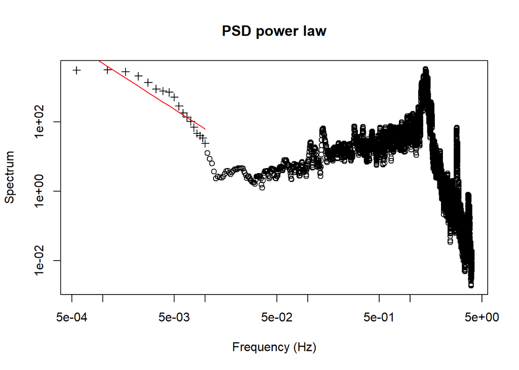

```r
hrv.data <- EstimatePSDSlope(hrv.data, indexFreqAnalysis = 2, regressionRange = NULL, doPlot = T, main = "PSD power law", xlab = "Frequency (Hz)", ylab = "Spectrum")
```

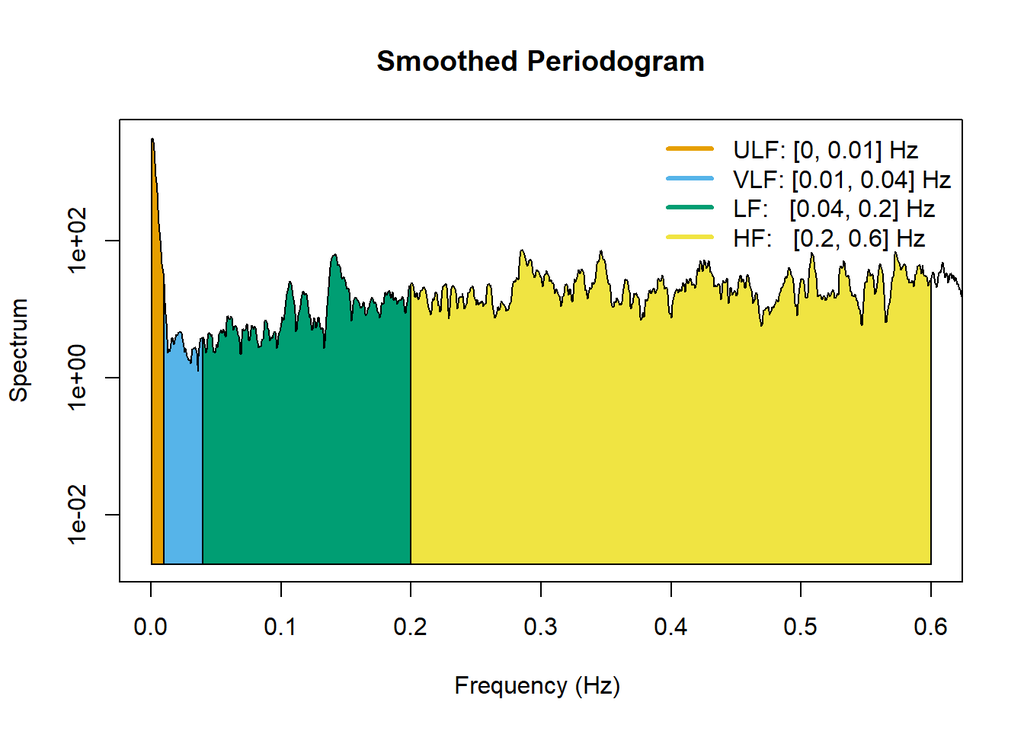

```r
PlotPSD(hrv.data, 2, addlegend = TRUE, ULFmin = 0, ULFmax = 0.01, VLFmin = 0.01, VLFmax = 0.04, LFmin = 0.04, LFmax = 0.2, HFmin = 0.2, HFmax = 0.6)
```

## Create powerband using wavelets

The most important function to perform nonstationary spectral HRV analysis is the CalculatePowerBand function. The CalculatePowerBand function computes the spectrogram of the RR series in the $ULF$, $VLF$, $LF$, and $HF$ frequency bands using $STFT$ or wavelets. Boundaries of the bands may be chosen by the user by specifying the values of the function parameters $ULFmin$, $ULFmax$, $VLFmin$, $VLF-max$, $LFmin$, $LFmax$, $HFmin$, and $HFmax$. If no boundaries are specified, the default values are:

$$ULF= (0: 0.03) Hz,$$
$$VLF=(0.03: 0.05) Hz,$$

$$LF= (0.05: 0.15) Hz,$$
and

$$HF= (0.15: 0.4) Hz.$$

Internally, the CalculatePowerBand function computes the spectrogram by using either $STFT$ or wavelets. The type of analysis can be selected by the user by specifying the type parameter. The possible values of this parameter are âfourierâ or âwaveletâ. Although the analysis based on wavelets is theoretically superior and more suitable for nonstationary signals, to maintain backwards compatibility in RHRV the default value for this parameter is âfourierâ. In the following subsections, we will see the parameters that can be specified when performing the analysis using Fourier and wavelets.

Given that the RR series is not stationary, it is often interesting to analyze the temporal evolution of the spectral power in the different bands. However, if the recording analyzed is short, or if we assume approximately stationary conditions over the recording, we may be interested in working with the average values of the spectral power in each of the bands. These average values are also computed by the function CalculatePowerBand and stored in the fields $ULF_{mean}$, $VLF_{mean}$, $LF_{mean}$, $HF_{mean}$, and $LFHF_{mean}$.

Wavelet: the mother wavelet used to calculate the spectrogram. Some of the most widely used wavelets are available: Haar (âhaarâ), extremal phase (âd4,â âd6,â âd8,â and âd16â), the least asymmetric Daubechies (âla8,â âla16,â and âla20â), and the best localized Daubechies (âbl14â and âbl20â) wavelets among others. The default value is âd4.â â¢ bandtolerance:maximumerrorallowedforthebandboundarieswhenthewavelet- based analysis is performed (see more details in [21, 22]). It can be specified as either an absolute or a relative error. The default value is 0.01. â¢ relative: a logic value specifying which type of band tolerance error shall be used: relative (in percentage) or absolute (this is the default value).

In the wavelet parameter, the name of the wavelet specifies the family (the family determines the shape of the wavelet and its properties) and the length of the wavelet. For example, $âla8â$ belongs to the least asymmetric family and has a length of 8 samples. Shorter wavelets usually have better temporal resolution, but they will tend to fail when discriminating close frequencies. On the other hand, longer wavelets usually have worse temporal resolution, but they provide better frequency resolution. Better temporal resolution means that we can study shorter-time intervals. Depending on the goal of the analysis, we can choose longer or shorter wavelets within a wavelet family.

Let $[fl,fu]$ be any frequency band specified, and let $[f1,f2]$ be a frequency interval associated with some node in the Maximal Overlap Discrete Wavelet Packet Transform $(MODWPT)$ tree. The relative error $Îµr$ of $fl$ over the $[f1,f2]$ interval is computed as:

$$Îµ_r = |\frac{f_l-f_1}{f_u-f_l}|·100%$$
Similarly, the relative error
$$Îµ_r$$
of the upper frequency
$$f_u$$
:
$$Îµ_r = |\frac{f_u-f_2}{f_u-f_l}|·100%$$

The use of a relative error has the advantage of avoiding large errors in the lower frequency bands (ULF and VLF bands). The absolute value $Îµ$ is defined as usual: $Îµ = |f2 â fu|$ for the upper frequency and $Îµ = |f1 â fl|$ for the lower frequency.

```r
hrv.data = CreateFreqAnalysis(hrv.data)
```

```
##  Creating frequency analysis
```

```
##  Data has now 3 frequency analysis
```

```r
hrv.data = CalculatePowerBand(hrv.data, indexFreqAnalysis = 3, type = "wavelet", wavelet = "d4", bandtolerance = 0.0025, relative = FALSE, ULFmin = 0, ULFmax = 0.01, VLFmin = 0.01, VLFmax = 0.04, LFmin = 0.04, LFmax = 0.2, HFmin = 0.2, HFmax = 0.6)
```

```
##  Calculating power per band
```

```
##  Using Wavelet analysis
```

```
##  Power per band calculated
```

```
##  Plotting power per band
```

```
##  Plotted LF/HF
```

```
##  Plotted ULF
```

```
##  Plotted VLF
```

```
##  Plotted LF
```

```
##  Plotted HF
```

```
##  Power per band plotted
```

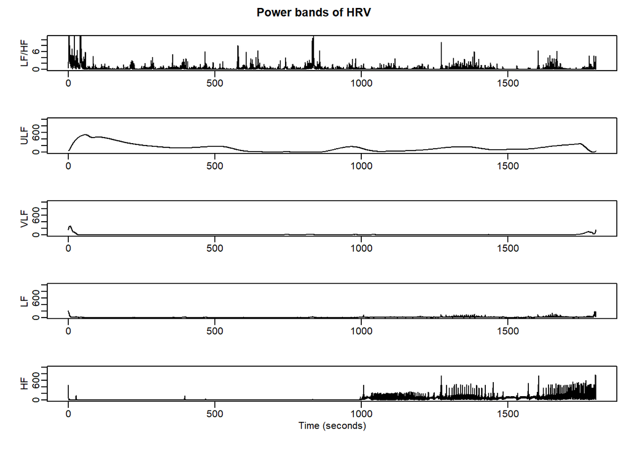

```r
PlotPowerBand(hrv.data, indexFreqAnalysis = 3, ymax = 1000, ymaxratio = 10, Tags = "all")
```

Since the energy is concentrated in the ULF band, the spectrogram representation may be hiding interesting information on the other bands (because its energy is negligible compared to the energy in the ULF band). Ploting the spectrogram ignoring the energy in the lowest frequencies componnents can negate this.

```
##  Plotting spectrogram
```

```
##  Calculating spectrogram
```

```
##  Window: 4800 samples (shift: 480 samples)
```

```
##  Window size for calculation: 8192  samples (zero padding: 3392  samples)
```

```
##  Signal size: 14398 samples
```

```
##  Windowing signal with 20 windows
```

```
##  Spectrogram calculated
```

```
##  Spectrogram plotted
```

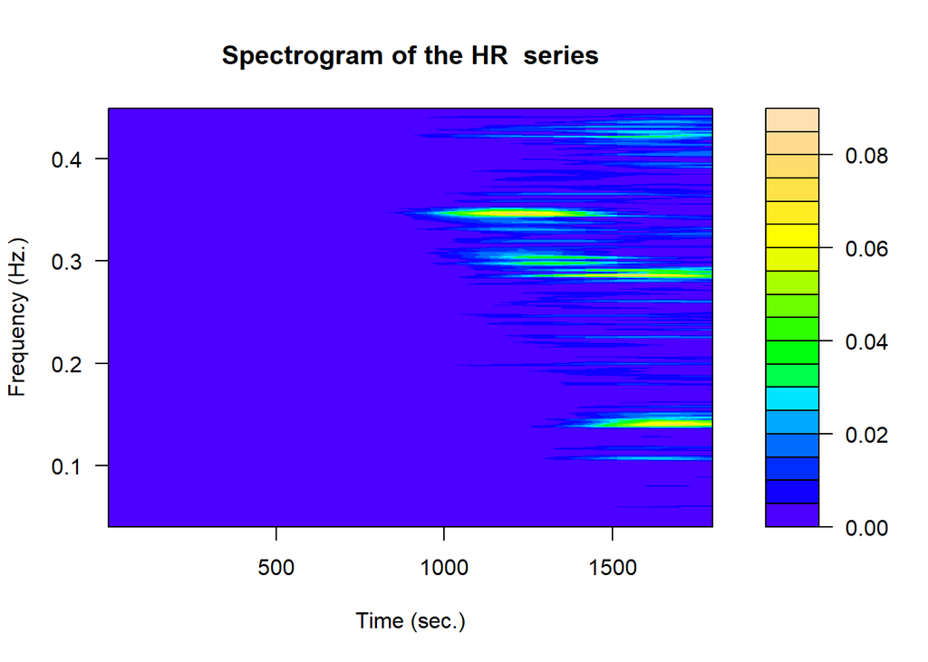

```r
spectrogram <- PlotSpectrogram(hrv.data, size = 600, shift = 60, scale = "logaritmic", freqRange = c(0.04, 0.45))
```

# Non-Linear analysis

## An overview of nonlinear dynamics

Most nonlinear time series analysis techniques used in the HRV literature are motivated by the theory of dynamical systems. A dynamical system is represented by a set of n state variables (that can be represented as coordinates in Rn) that fully describe the state of the system at any time, and a dynamical rule that specifies the future values of all the state variables. The collection of coordinates is usually referred to as the phase space if these coordinates form a smooth manifold. There can be multiple spaces of states representing a dynamical system; i.e., the system representation is not unique. Dynamical systems can be deterministic (the future state is fully determined by the dynamical rule), or stochastic/random (there is a probability distribution defined over the future states).

In the context of HRV analysis, many successful approaches assume that the RR series is a deterministic nonlinear process (with possibly a small linear random perturbation). In my analysis, when applying techniques derived from deterministic nonlinear dynamics to the $RR$ series, I will shall assume that the HR regulation system is dissipative, and thus, the system will be attracted, after some transient, to a subset attractor. Furthermore, I will focus on discrete deterministic dynamical systems, given that the major approach in $HRV$ literature focuses on studying how the current RR interval, $RRi$, determines the next one, $RRi+1$.

Nonlinear stochastic systems can be viewed as a combination of deterministic systems and stochastic models. There is a low use of nonlinear stochastic models in HRV due to the success in the application of a particular type of stochastic processes to the $RR$ series: fractal models.

## Hypothesis testing:

I first need to reject the null hypothesis: “This dataest was generated by some collection of linear processes”

The main idea for testing for nonlinearity is the following. A statistic $Î¼$ quantifying some nonlinear feature of the data is computed. Does the value found for $Î¼$ (Î¼data) suggest nonlinearity or can we explain this value with a simpler hypothesis? If we know the distribution of $Î¼$ for a linear process, we can test if $Î¼$ data gives enough evidence for assuming a nonlinear model. However, we do not usually know the distribution of Î¼ under the null hypothesis. The preferred approach in the literature is estimating this distribution by using an ensemble of surrogate data.

This ensemble is generated in such a way that each realization shares the linear properties of the original time series. For a two-sided test and a level of significance $Î±,$ $2K/Î± â 1$ surrogates are usually generated (K is an integer, $K â¥ 1$, controlling the final number of surrogates). Under the null hypothesis, there are $2K/Î±$ samples following the same distribution. Thus, each of this samples has a probability of $Î±/2$ of yielding one of the smallest K values of Î¼, and a probability of $Î±/2$ of yielding one of the largest values of $Î¼$. The null hypothesis is then rejected when the observed time series yields either one of the K smallest or largest values. For a one-sided test, only K /Î± â 1 surrogates are needed, and we reject the null hypothesis when the time series yields one of the K smallest/largest value of Î¼ (depending on the particular hypothesis).

To do this I will employ a variety of statistical tests: â¢ Teraesvirta’s neural metwork test for nonlinearity â¢ White neural metwork test for nonlinearity â¢ Keenan’s one-degree test for nonlinearity â¢ Perform the McLeod-Li test for conditional heteroscedascity (ARCH). â¢ Perform the Tsay’s test for quadratic nonlinearity in a time series. â¢ Perform the Likelihood ratio test for threshold nonlinearity.

This tests the null hypothesis stating that the series is a gaussian linear process or was generated by some combination of linear processes. The test is performed by generating several surrogate data according to H0 and comparing the values of a discriminating statistic between both original data and the surrogate data. If the value of the statistic is significantly different for the original series than for the surrogate set, the null hypothesis is rejected, and nonlinearity assumed.

The surrogate data is generated by using a phase randomization procedure. $\alpha = 0.05$, $timeAsymmetry = 2$, $\tau = 4$

```r
# Nonlinear analysis
#Statistical tests for non-linearity
hrv.data = NonlinearityTests(hrv.data)
```

```
##  Performing nonlinearity tests
```

```
##       ** Teraesvirta's neural network test  **
##       Null hypothesis: Linearity in "mean"
##       X-squared =  5099.589  df =  2  p-value =  0
##
##       ** White neural network test  **
##       Null hypothesis: Linearity in "mean"
##       X-squared =  4853.818  df =  2  p-value =  0
##
##       ** Keenan's one-degree test for nonlinearity  **
##       Null hypothesis: The time series follows some AR process
##       F-stat =  0.1962702  p-value =  0.6577667
##
##       ** McLeod-Li test  **
##       Null hypothesis: The time series follows some ARIMA process
##       Maximum p-value =  0
##
##       ** Tsay's Test for nonlinearity **
##       Null hypothesis: The time series follows some AR process
##       F-stat =  2.214  p-value =  9.554e-53
##
##       ** Likelihood ratio test for threshold nonlinearity **
##       Null hypothesis: The time series follows some AR process
##       Alternativce hypothesis: The time series follows some TAR process
##       X-squared =  209.544  p-value =  0
```

```
## Computing statistics
```

```
## Null Hypothesis: Data comes from a linear stochastic process
```

```
## Accept Null hypothesis
```

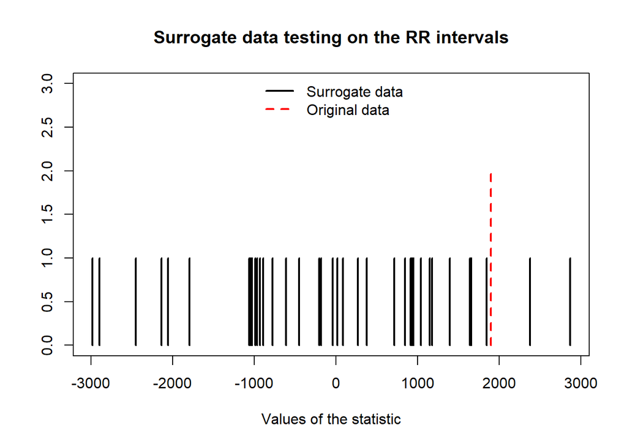

```r
hrv.data = SurrogateTest(hrv.data, significance = 0.05, useFunction = timeAsymmetry, doPlot = TRUE)
```

```
## Computing statistics
```

```
## Null Hypothesis: Data comes from a linear stochastic process
```

```
## Accept Null hypothesis
```

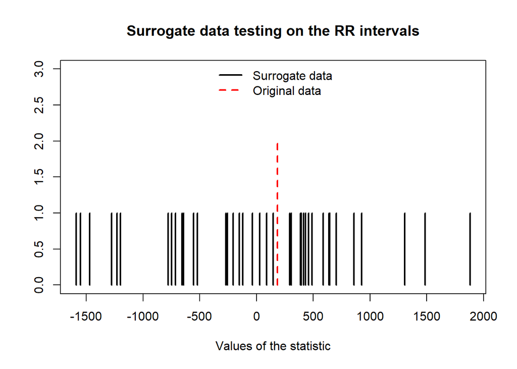

```r
hrv.data = SurrogateTest(hrv.data, significance = 0.05, useFunction = timeAsymmetry2, tau = 4, doPlot = TRUE)
```

## Perfom a phase space reconstruction

When observing a highly complex system (such as the HR modulation system), typically I am only able to measure a few of the dynamical variables governing the evolution of the system. In the case of HRV analysis, I usually only measure the RR intervals instead of the (unknown) set of state variables. I need a mechanism to derive the state space from the $RR$ intervals. This problem receives the name of phase space reconstruction, and it is formally solved by using the embedding theorem. This theorem states that a phase space can be reconstructed from the single measured discrete series $x_i$ by using the vectors: ô°ô°
$$xi = xi , xi+Ï , ..., xi+(mâ1)Â·Ï ,$$

where $m$ and $Ï$ will be referred to as the embedding dimension and the time-lag parameter.

Great effort has been made to clarify under which circumstances leads to proper phase space reconstruction. This is guaranteed if $m$ is larger than twice the dimension of the true phase space. However, the true embedding dimension of the attractor is usually unknown in practical applications. The most widely used method for selecting the embedding dimension is based on the concept of false neighbour. Let us suppose that I have built a phase space reconstruction using an embedding dimension $m$ and a time lag $Ï$ . Given a specific vector $xi$, I shall denote its nearest neighbor in the phase space by $xnn$. If $xnn$ is a true neighbor of $xi$, then it should have arrived to a neighborhood of $xi$ through the dynamical rules of the system. On the other hand, if $xnn$ is a false neighbor, then it may have arrived to a neighborhood of $xi$ because during the phase space reconstruction process I have projected the $d$-dimensional attractor into an $m$-dimensional space, $d > m$. If I have false neighbors in a given reconstruction, by increasing the dimension of the reconstructed phase space, I should decrease the number of false neighbors. When I reach the real dimension, only the real neighbors should remain in the neighborhood of the point, while false neighbors should disappear. Henceforth, increasing the size of the reconstructed space should not decrease the number of neighbors. Thus, the key idea behind the most widely used algorithms for selecting a proper phase space dimension is searching for the minimum dimension in which most of the false neighbors have been eliminated. RHRV package implements one of the best-known algorithm based on false neighbors, the Cao algorithm.

Selecting a proper time lag parameter $Ï$ is also important when embedding the vectors in an $m$-dimensional phase space. If $Ï$ is small compared to the time scale that the system needs to manifest noticeable changes, successive elements of the phase space will be highly correlated. Thus, they will tend to cluster around the diagonal of $Rm$ . On the other hand, if $Ï$ is too large, the phase space elements will be independent; thus, the resulting embedding will tend to spread in $Rm$ . The first zero in the autocorrelation function of the signal is often selected as a compromise between these extreme situations. The first minimum or the $1/e$ value of the autocorrelation function is also used as selection criterion for $Ï$ .

This procedure is sometimes criticized because the selection of $Ï$ relies on a linear statistic (the autocorrelation), and thus, it does not take into account the nonlinear correlations of the process. Fraser et al. suggested the use of the average mutual information $(AMI)$ between the time series and a delayed version of itself for selecting the time lag parameter. The AMI function, $AMI[Ï]$, quantifies the amount of knowledge gained about the value of $x_{i+k}$ when observing xi by studying the probability distribution of $(x_i,x_{i+Ï})$. The first minimum or the first 1/$e$ decay of $AMI[Ï]$ is commonly used for selecting the time lag parameter $Ï$.

In the next sections, a brief theoretical discussion of the nonlinear deterministic techniques implemented in RHRV is presented.

According to Takenâs therom, it is possible to build a smooth attractor from observations of a general function. The correctly generated manifold reconstruction will have the same mathematical properties such as its topological characteristics and Lyapunov exponent.

To perform the phase space reconstruction I need to define two variables, the timelag of the function and the dimension in which the embed the manifold reconstruction.

To calculate the $\tau$ I will use the $AMI$ algorithm.

A basic criterion for estimating a proper time lag is based on the following reasoning: if the time lag used to build the Takens’ vectors is too small, the coordinates will be too highly temporally correlated and the embedding will tend to cluster around the diagonal in the phase space.

Estimation of the Embedding dimension This function determines the minimum embedding dimension from a scalar time series using the algorithm proposed by L. Cao. The Cao algorithm computes two time series ($E1D$ and $E2D$). The $E1D$ time series will reach a value of one and stay at 1 when proper phase space reconstruction has been achieved. $ED2 \approx 1$ when the data is stochastic and is otherwise deterministic.

```
##  Calculating optimum time lag
```

```
##  Time Lag = 1
```

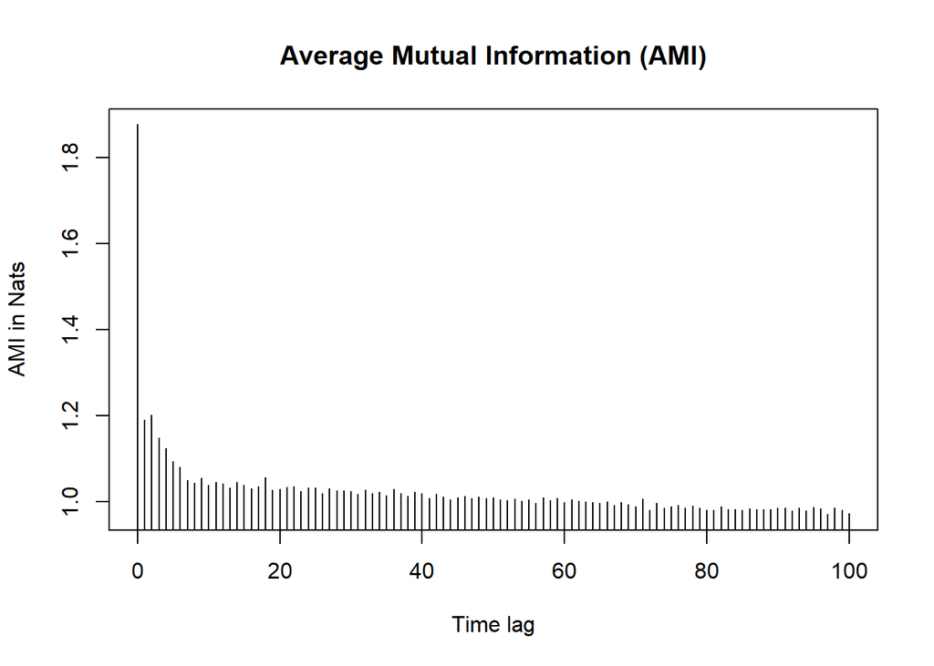

```r
# These functions calculate the time lag and the embedding dimension used to perform phase space reconstruction
kTimeLag = CalculateTimeLag(hrv.data, technique = "ami", method = "first.minimum", lagMax = 100, doPlot = TRUE)
```

```
##  Estimating embedding dimension
```

```
##  Embedding Dimension = 12
```

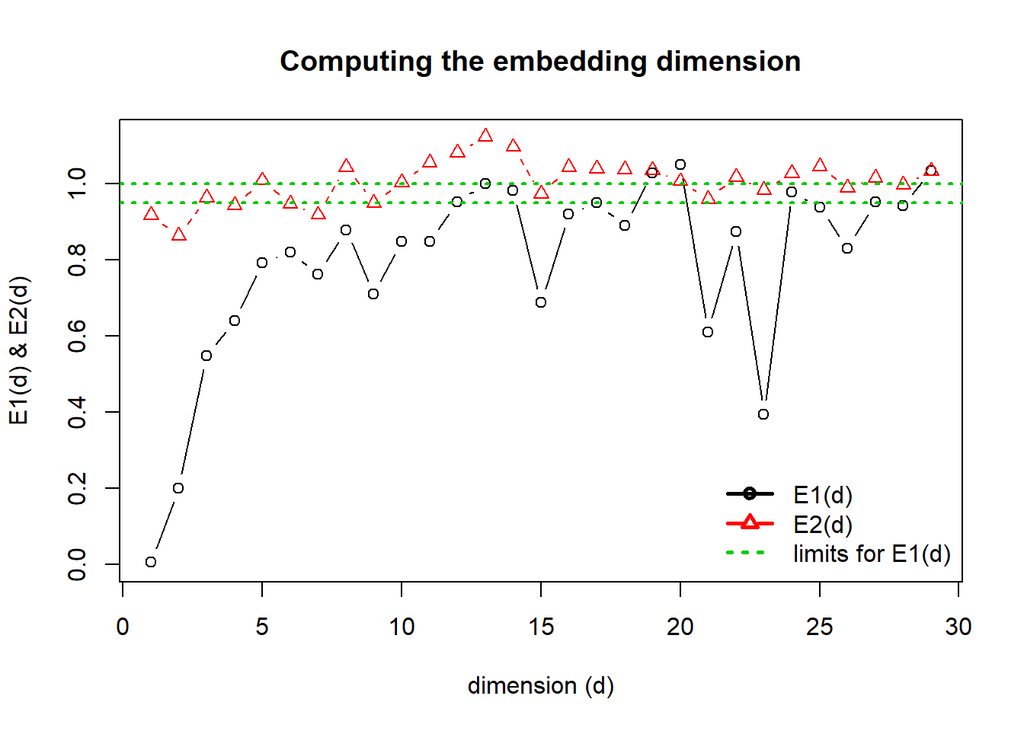

```r
kEmbeddingDim = CalculateEmbeddingDim(hrv.data, numberPoints = 1000, timeLag = kTimeLag, maxEmbeddingDim = 30, threshold = 0.95, maxRelativeChange = 0.05, doPlot = TRUE)
```

```r
takens <- BuildTakens(hrv.data, embeddingDim = kEmbeddingDim, timeLag = kTimeLag)
scatter3D(takens[, 1], takens[, 2], takens[, 3],
main = "3D projection of the HR attractor",
phi = 20, theta = 30,
type = "l", col = 1)
```

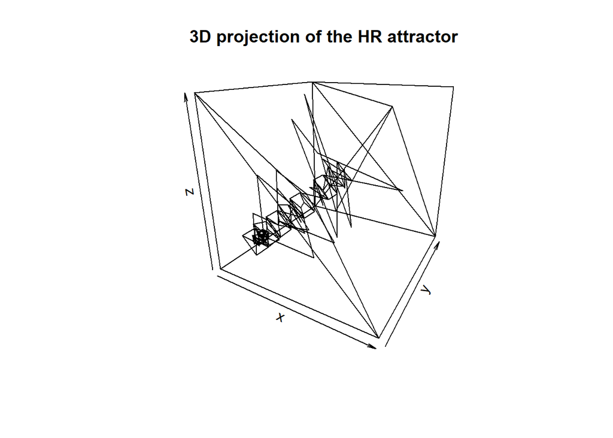

Due to the low sampling rate, we must reduce the noise component.